# Scikit-learn

# LightGBM

lightGBM 有两种方法控制增量学习模式：

- 如果 init_model 不为 None，将从原有模型基础上继续训练，添加 num_boost_round 棵新树
- 调用 refit 任务，将在原有模型的树结构都不变的基础上，重新拟合新数据更新叶子节点权重

## 设置 init_model 参数增加新树

```python
import lightgbm as lgb
```

```python
# specify parameters via map
params = dict(
    boosting_type = 'gbdt',
    objective = 'binary',
    metric = 'auc',
    is_unbalance = True,
    learning_rate = 0.015,
    max_depth = 8,
    feature_fraction = 0.35,
    bagging_fraction = 1.0,
    lambda_l1 = 65,
    lambda_l2 = 15,
    subsample_freq = 5,
    random_state = SEED,
    verbosity = -1
)
```

```python
gbm = None   # init model

# Train 1200 iterations, with the each chunk runs for 100 iterations.
def lgb_continue(X_train, y_train, X_test, y_test, i=None):
    dtrain = lgb.Dataset(X_train, label=y_train)
    dtest = lgb.Dataset(X_test, label=y_test)
    global gbm
    gbm = lgb.train(
        params,
        dtrain,
        num_boost_round = 100,
        init_model = gbm,
        valid_sets = [dtrain],
        callbacks = [lgb.early_stopping(stopping_rounds=20)],
        keep_training_booster=True
    )
    train_pred = gbm.predict(X_train)
    test_pred = gbm.predict(X_test)
    return train_pred, test_pred, gbm.num_trees()

minibatch_iterator = get_minibatch(minibatch_size = batch_size)
auc_history = incremental_learning(minibatch_iterator, lgb_continue)
```

```
test data shape: (75000, 158)
100 trees, valid's auc: 0.7179 in 0.67s
200 trees, valid's auc: 0.7301 in 1.59s
300 trees, valid's auc: 0.7372 in 2.68s
400 trees, valid's auc: 0.7420 in 3.92s
500 trees, valid's auc: 0.7447 in 5.32s
600 trees, valid's auc: 0.7461 in 6.83s
700 trees, valid's auc: 0.7482 in 8.52s
800 trees, valid's auc: 0.7486 in 10.33s
900 trees, valid's auc: 0.7488 in 12.28s
1000 trees, valid's auc: 0.7494 in 14.39s
1100 trees, valid's auc: 0.7500 in 16.64s
1200 trees, valid's auc: 0.7506 in 18.64s
finally:
  train's auc: 0.7768
  valid's auc: 0.7506
```

其中 keep_training_booster (bool) 参数表示返回的模型 (booster) 是否将用于保持训练，默认 False。当模型非常大并导致内存错误时，可以尝试将此参数设置为 True，以避免 model_to_string 转换。然后仍然可以使用返回的 booster 作为 init_model，用于未来的继续训练。

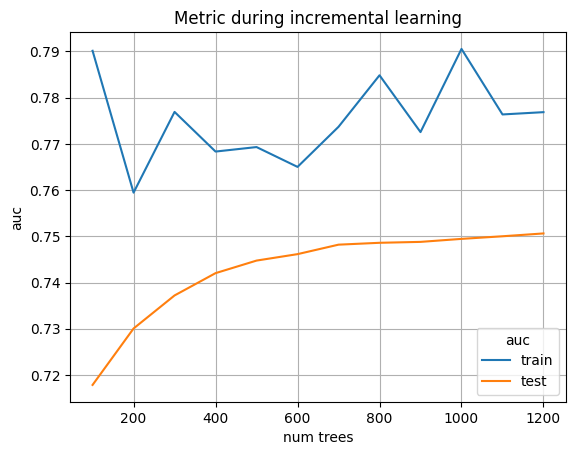

```python
plot_score_evolution(auc_history, 'num trees')
plt.show()
```

## 刷新叶子节点

```python
# specify parameters via map
params = dict(
    boosting_type = 'gbdt',
    objective = 'binary',
    metric = 'auc',
    is_unbalance = True,
    learning_rate = 0.015,
    max_depth = 8,
    feature_fraction = 0.35,
    bagging_fraction = 1.0,
    lambda_l1 = 65,
    lambda_l2 = 15,
    subsample_freq = 5,
    random_state = SEED,
    verbosity = -1
)
```

```python
gbm = None   # init model

# The model will adapt to new data by changing leaf value (no change in split condition)
def lgb_refit(X_train, y_train, X_test, y_test, i=None):
    dtrain = lgb.Dataset(X_train, label=y_train)
    dtest = lgb.Dataset(X_test, label=y_test)
    # update estimator with examples in the current mini-batch
    global gbm
    gbm = lgb.train(
        params,
        dtrain,
        num_boost_round = num_rounds,
        init_model = gbm,
        valid_sets = [dtrain],
        keep_training_booster=True
    )
    train_pred = gbm.predict(X_train)
    test_pred = gbm.predict(X_test)
    if i == 0:
        params['task'] = 'refit'
        params['refit_decay_rate'] = 0.9
    return train_pred, test_pred, None

minibatch_iterator = get_minibatch(minibatch_size = batch_size)
auc_history = incremental_learning(minibatch_iterator, lgb_refit)
```

```
test data shape: (75000, 158)
20000 train samples, valid's auc: 0.7373 in 5.65s
40000 train samples, valid's auc: 0.7423 in 12.74s
60000 train samples, valid's auc: 0.7423 in 21.02s
80000 train samples, valid's auc: 0.7424 in 30.64s
100000 train samples, valid's auc: 0.7438 in 42.43s
120000 train samples, valid's auc: 0.7409 in 56.15s
140000 train samples, valid's auc: 0.7419 in 72.42s
160000 train samples, valid's auc: 0.7394 in 91.47s
180000 train samples, valid's auc: 0.7363 in 114.02s
200000 train samples, valid's auc: 0.7386 in 140.03s
220000 train samples, valid's auc: 0.7360 in 170.18s
232511 train samples, valid's auc: 0.7347 in 198.44s
finally:
  train's auc: 0.8629
  valid's auc: 0.7347
```

其中 refit_decay_rate 控制 refit 任务中叶节点输出的衰减率。重新拟合后，叶子结点的输出的计算公式为：  
`leaf_output = refit_decay_rate * old_leaf_output + (1.0 - refit_decay_rate) * new_leaf_output`

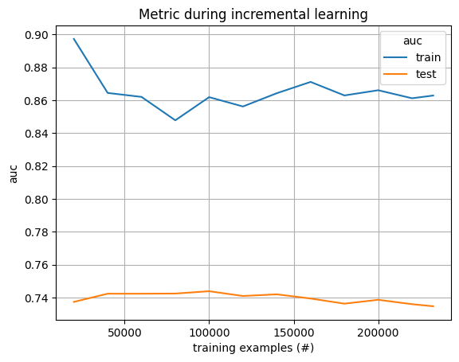

```python
plot_score_evolution(auc_history, 'training examples (#)')
plt.show()
```